# Diffusion Distance

Youjin Lee

Diffusion distance provides the multiscale geometrics for nodes in network space. Especially, we want to show its sensitivity to local structures.

## Distance in Network Space

Adjacency matrix or geodesic distance (the length of shortest path connecting a pair of nodes) holds positive-definity, but adjacency matrix or similarity matrix disobeys identity of indiscernibles unless every pair of node is adjacent each other. Both adjacency and geodesic distance disobeys triangle identity.

Suppose $G$ is a connected, undirected graph. On the other hand, diffusion distance at diffusion time $t$, $D_{t} : u \times v \rightarrow [0, \infty)$ satisfies the following conditions required for being a proper metric:

1. $D_{t}(u, v) \geq 0$
2. $D_{t}(u,v) = 0 \Leftrightarrow u = v$ (if and only if $G$ is connected.)
3. $D_{t}(u,v) = D_{t}(v,u)$ (if and only if $G$ is undirected.)
4. $D_{t}(u,v) \leq D_{t}(u,w) + D_{t}(w,v)$ proof of triangle inequality

[Coifman $\&$ Lafon](http://ac.els-cdn.com/S1063520306000546/1-s2.0-S1063520306000546-main.pdf?_tid=551a6f5e-33e3-11e6-aee2-00000aab0f6c&acdnat=1466096396_e605dca62dc945ba759fe647a407d02f) showed that the diffusion maps offer a representation of the data as a clude of points in a Euclidean space, by proving that the diffusion map embeds the data into the Euclidean space, so that in this space, the Euclidean distance is equal to the diffusion distance.

## Comparison between distance metrics

### [sim] two.8 simulation

$X \sim Bern(0.5)$

$Z \sim \left\{ \begin{array}{cc} Bern(0.6) & X = 0 \\ Bern(0.4) & X = 1 \end{array} \right.$

$A \sim Bern \left[ \begin{array}{cc} \color{red}{0.3} & 0.05 \\ 0.05 & \color{blue}{0.2} \end{array} \right]$

#### Power

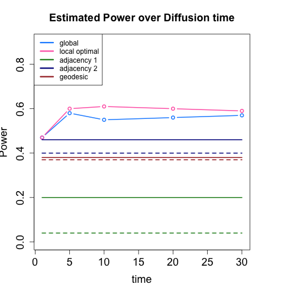

#### Diffusion Process

- t = 1

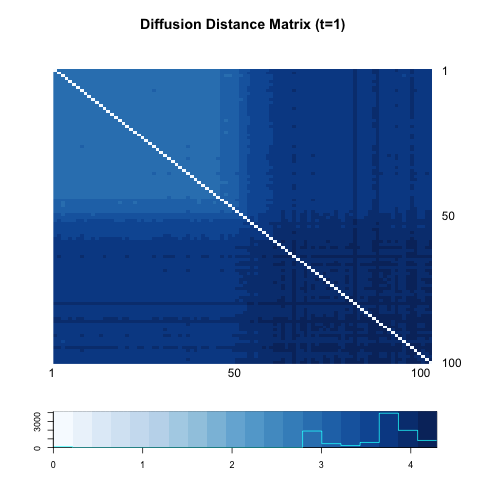

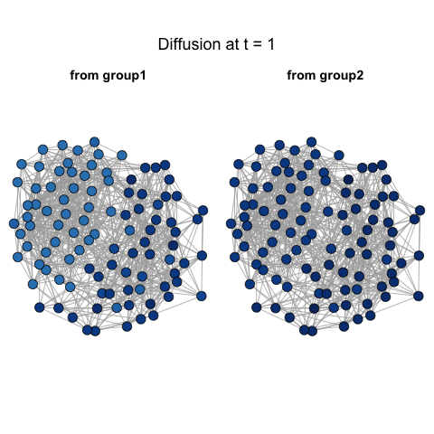

- t = 5

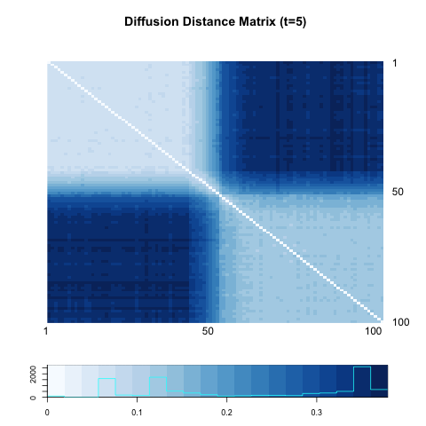

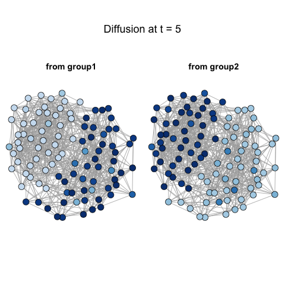

- t = 30

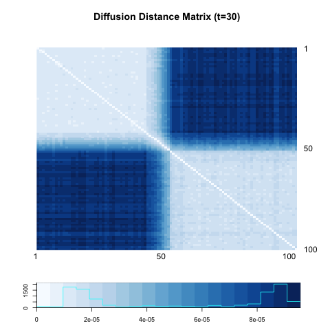

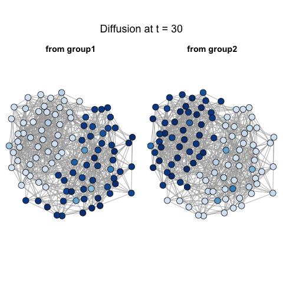

#### Other distance measure

- Non-adjacency (dissimilarity)

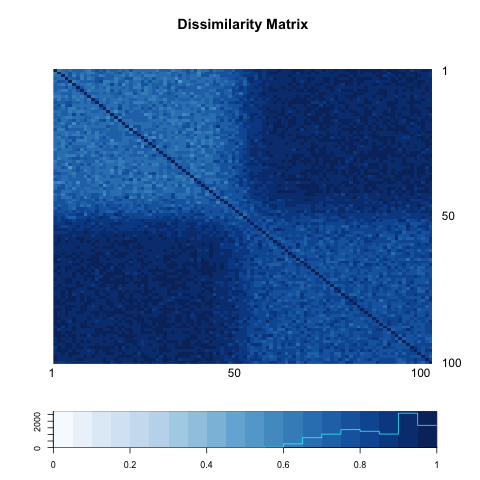

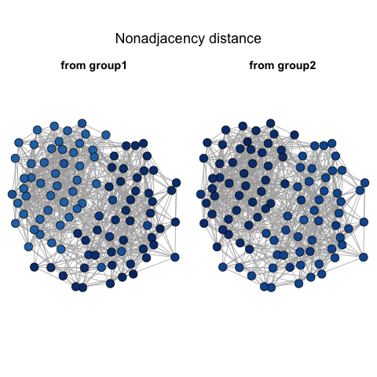

- Euclidean Distance of dissimilarity matrix

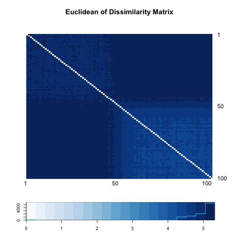

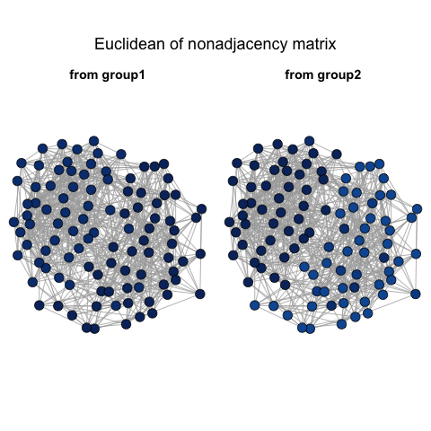

- Geodesic Distance

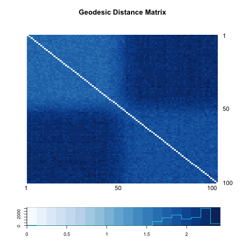

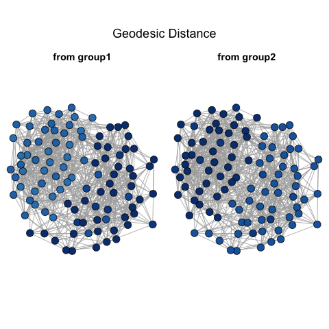

### [sim] two.9 simulation

$X \sim Bern(0.5)$

$Z \sim \left\{ \begin{array}{cc} Bern(0.6) & X = 0 \\ Bern(0.4) & X = 1 \end{array} \right.$

$A \sim Bern \left[ \begin{array}{cc} \color{red}{0.3} & 0.1 \\ 0.1 & 0.1 \end{array} \right]$

#### Power

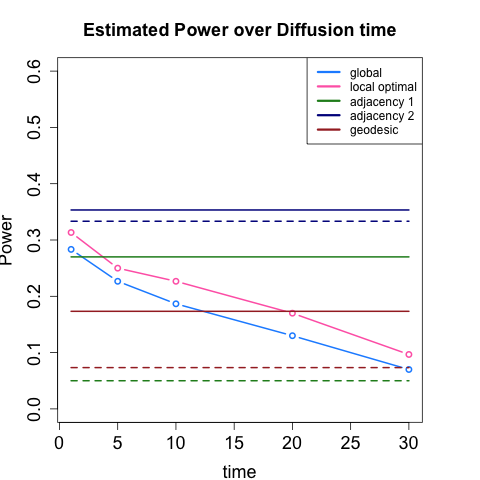

### [sim] two.10 simulation

$X \sim Bern(0.5)$

$Z \sim \left\{ \begin{array}{cc} Bern(0.6) & X = 0 \\ Bern(0.4) & X = 1 \end{array} \right.$

$A \sim Bern \left[ \begin{array}{cc} \color{red}{0.1} & 0.3 \\ 0.3 & 0.3 \end{array} \right]$

#### Power

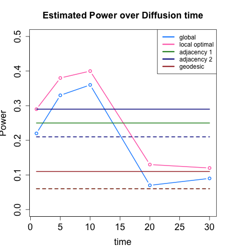

#### Diffusion Process

- t = 1

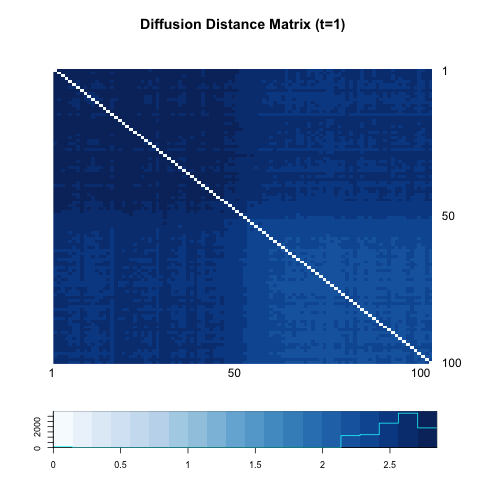

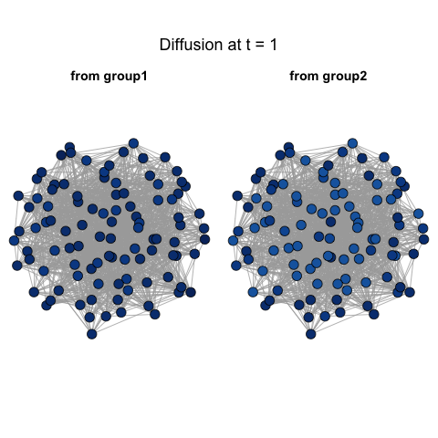

- t = 10

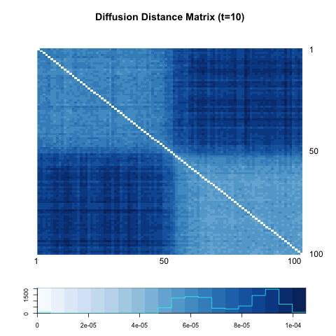

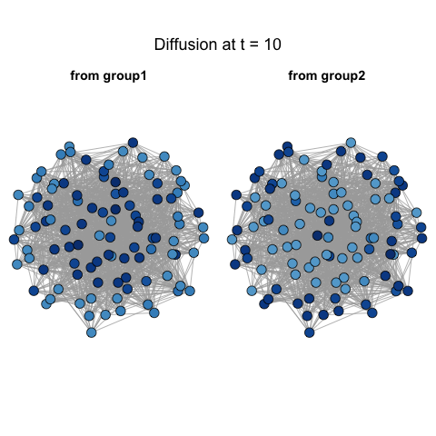

- t = 20

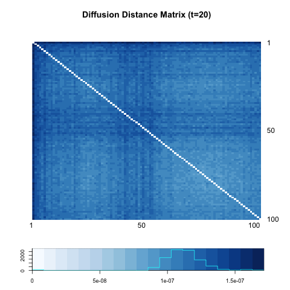

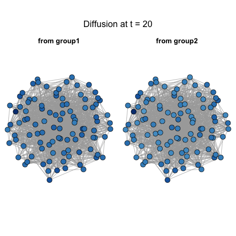

#### Other distance measure

- Non-adjacency (dissimilarity)

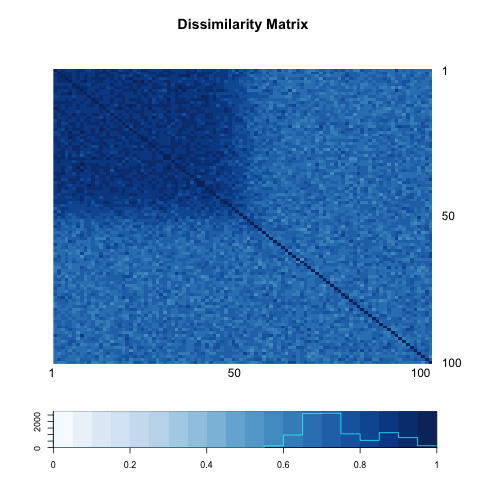

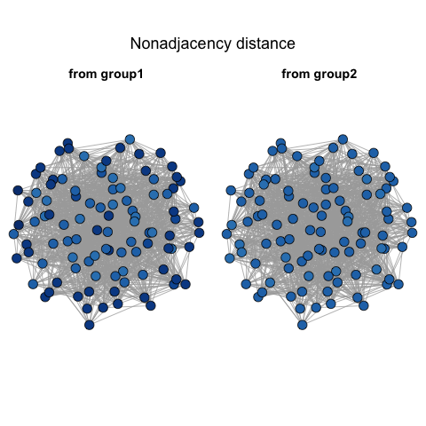

- Euclidean Distance of dissimilarity matrix

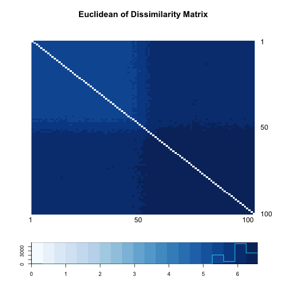

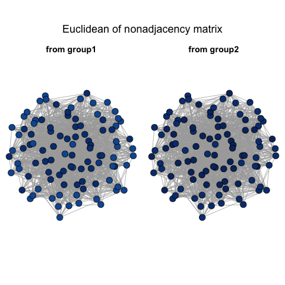

- Geodesic Distance

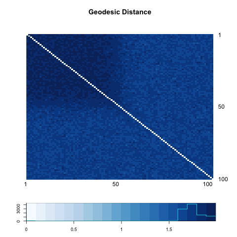

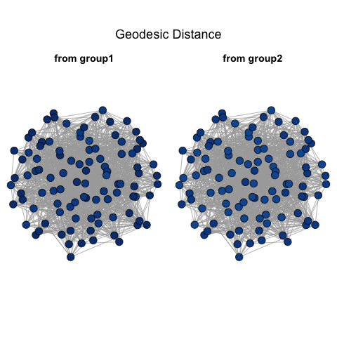